# Answering Questions in the RI Hospital Dataset

```python
import matplotlib
import matplotlib.pyplot as plt
import seaborn as sns
%matplotlib inline
import pandas as pd
df = pd.read_csv (r'Hospital_Data.csv')
```

```python
df.head(1)
```

|  | yod | yoa | provider | trandb | payer | randbg | randbs | tot | anes | ther | ... | er_fee | dx8 | er_chrg | px1 | dx7 | preopday | filler6 | px2 | bwght | Test_Sex |
| --- | --- | --- | --- | --- | --- | --- | --- | --- | --- | --- | --- | --- | --- | --- | --- | --- | --- | --- | --- | --- | --- |
| 0 | 2010.0 | 2010.0 | 7214 | 5250 | G | 5250 | 0 | 14150.0 | 00000900 | 23800 | ... | NaN | NaN | NaN | 7569 | NaN | 1.0 | NaN | NaN | NaN | 2.0 |

1 rows × 61 columns

# Questions to Answer:

1. What is the average charge for each payer (insurance) over time?
2. What is every patient’s state of residence?
3. What is the average total charge for each hospital?
4. What is the most common race/ethnicity of patients for each hospital?
5. What is the most common month for patients to enter the hospital?

# #1 What is the average charge for each payer (insurance) over time?

Reference for visualizations: https://scentellegher.github.io/programming/2017/07/15/pandas-groupby-multiple-columns-plot.html

To make everything viewable, I first split the dataset by payer multiple times to get 3 to 4 payers per subplot. Otherwise, it would be difficult to view a single graph that has 15 lines.

```python
df1= df[['yod','payer', 'tot']].copy()
df1.head()
```

|  | yod | payer | tot |
| --- | --- | --- | --- |
| 0 | 2010.0 | G | 14150.0 |
| 1 | 2010.0 | G | 2684.0 |
| 2 | 2010.0 | G | 7767.0 |
| 3 | 2010.0 | G | 5315.0 |
| 4 | 2010.0 | G | 31107.0 |

```python
df2 = df1[df1['payer'].isin(['0','1','4','5'])]
df2.head()
```

|  | yod | payer | tot |
| --- | --- | --- | --- |
| 21 | 2010.0 | 0 | 36155.0 |
| 22 | 2010.0 | 5 | 2784.0 |
| 23 | 2010.0 | 5 | 3361.0 |
| 24 | 2010.0 | 5 | 14983.0 |
| 25 | 2010.0 | 5 | 12906.0 |

```python
df333 = df1[df1['payer'].isin(['6','7','8','B'])]
#df333.head()
```

```python
df666= df1[df1['payer'].isin(['D','E','G','H'])]
#df666.head()
```

```python
df667= df1[df1['payer'].isin(['X','Y','Z'])]
```

Now I rename each payer to what it corresponds to in the data dictionary.

```python
Payer_df = pd.DataFrame([['0', 'Medicare'],
                             ['1', 'Medicaid'],
                             ['4', 'Workers Compensation'],
                             ['5', 'Blue Cross'],
                             ['6', 'Commercial Insurance'],
                             ['6', 'Commercial Insurance'],
                             ['7', 'Self Pay'],
                             ['8', 'Other'],
                             ['B', 'Champus'],
                             ['D', 'United Healthcare'],
                             ['E', 'Coordinated Health Partners Inc'],
                             ['G', 'Rite Care'],
                             ['H', 'Neighborhood Health Plan of RI'],
                             ['X', 'Insurance Errror'],
                             ['Y', 'Misssing'],
                             ['Z', 'Unknown']])

df2['payer'] = df2['payer'].replace(list(Payer_df[0]),list(Payer_df[1]))
df333['payer'] = df333['payer'].replace(list(Payer_df[0]),list(Payer_df[1]))
df666['payer'] = df666['payer'].replace(list(Payer_df[0]),list(Payer_df[1]))
df667['payer'] = df667['payer'].replace(list(Payer_df[0]),list(Payer_df[1]))
```

Next, we plot the data:

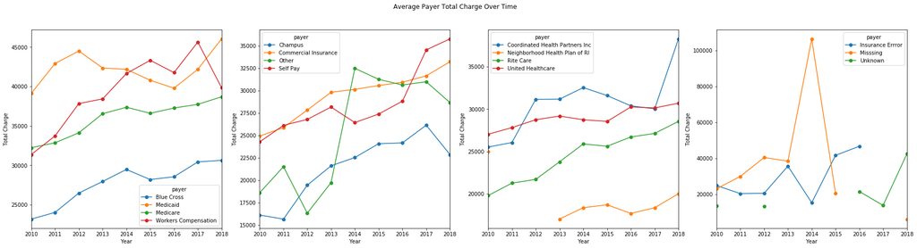

```python
fig, ax =plt.subplots(1,4, figsize=(30,7))
df2.groupby(['yod','payer']).mean()['tot'].unstack().plot(ax=ax[0], marker='o')
df333.groupby(['yod','payer']).mean()['tot'].unstack().plot(ax=ax[1], marker='o')
df666.groupby(['yod','payer']).mean()['tot'].unstack().plot(ax=ax[2], marker='o')
df667.groupby(['yod','payer']).mean()['tot'].unstack().plot(ax=ax[3], marker='o')


for i in ax.flat:
    i.set(xlabel='Year', ylabel='Total Charge')

fig.suptitle('Average Payer Total Charge Over Time')
fig.show()
```

The above charts are a bit misleading because they do not share the same y-axis. Some charts go up to 45,000 while others can go above 100,000. Also, if there is a break in the lines, that is because there is no data in consecutive years.

# #2 What is every patient’s state of residence?

We start off by getting the data we want for this question and removing irrelevant features.

```python
df22= df[['yod', 'pt_state']].copy()
df22["pt_state"] = df["pt_state"].astype("str")
df22.head()
```

|  | yod | pt_state |
| --- | --- | --- |
| 0 | 2010.0 | 00 |
| 1 | 2010.0 | 00 |
| 2 | 2010.0 | 00 |
| 3 | 2010.0 | 00 |
| 4 | 2010.0 | nan |

```python
df22 = df22[df22['pt_state'].isin(['AL', 'AK', 'AZ', 'AR', 'CA', 'CO', 'CT', 'DE', 'FL', 'GA', 'HI', 'ID', 'IL', 'IN',
                                   'IA', 'KS', 'KY', 'LA', 'ME', 'MD', 'MA', 'MI', 'MN', 'MS', 'MO', 'MT', 'NE', 'NV',
                                   'NH', 'NJ', 'NM', 'NY', 'NC', 'ND', 'OH', 'OK', 'OR', 'PA', 'RI', 'SC', 'SD', 'TN',
                                   'TX', 'UT', 'VT', 'VA', 'WA', 'WV', 'WI', 'WY'])]
df22.head()
```

|  | yod | pt_state |
| --- | --- | --- |
| 9 | 2010.0 | RI |
| 34 | 2010.0 | RI |
| 48 | 2010.0 | RI |
| 51 | 2010.0 | RI |
| 56 | 2010.0 | RI |

```python
num3= df22.groupby(['pt_state'])['yod'].count().sort_values(ascending=False)
num3.to_frame().head(1)
```

| pt_state | yod |
| --- | --- |
| RI | 215006 |

Now we generate the choropleth map to visualize our cleaned data. I like this because if you hover the mouse over a state you will see it is interactive and will give you information on where your mouse is. The top right of the visualization gives you other tools to use, like zooming in and out.

```python
import plotly.graph_objects as go
import pandas as pd

fig = go.Figure(data=go.Choropleth(
    locations= ["AL", "AK", "AZ", "AR", "CA",
                "CO", "CT", "DE", "FL", "GA",
                "HI", "ID", "IL", "IN", "IA",
                "KS", "KY", "LA", "ME", "MD",
                "MA", "MI", "MN", "MS", "MO",
                "MT", "NE", "NV", "NH", "NJ",
                "NM", "NY", "NC", "ND", "OH",
                "OK", "OR", "PA", "RI", "SC",
                "SD", "TN", "TX", "UT", "VT",
                "VA", "WA", "WV", "WI", "WY"], # Spatial coordinates
    z = [8, 5, 24, 3, 86,
         10, 4456, 3, 406, 29,
         3, 2, 27, 8, 1,
         5, 6, 4, 70, 50,
         17375, 22, 10, 7, 7,
         4, 1, 9, 111, 90,
         4, 280, 44, 2, 23,
         5, 6, 76, 215006, 38,
         2, 9, 31, 8, 21,
         51, 13, 3, 6, 1], # Data to be color-coded

    # Unfortunately, I was running into errors when I tried to set the locations and z to columns in the dataframe,
    # so I ended up having to input the raw data into both to get it to work.

    locationmode = 'USA-states', # set of locations match entries in `locations`
    colorscale = [[0, "rgb(255,250,250)"],
                [0.00005, "rgb(255,220,219)"],
                [0.0005, "rgb(255,175,174)"],
                [0.02, "rgb(237,115,114)"],
                [1, "rgb(255,3,0)"]],
    #'Reds',

    colorbar= dict(
        tick0= 0,
        #tickmode= 'array',
        tickvals= [0, 25000, 100000, 150000, 215000, 220000]
    ),
    colorbar_title = "Total Cases",
))

fig.update_layout(
    title_text = 'Patient State of Origin',
    geo_scope='usa', # limite map scope to USA
)

fig.show()
```

[interactive chart not shown]

As you would imagine, this dataset is heavily skewed towards RI considering this is a RI hospital dataset. This means the color scheme changes radically at the lower end. If there was a more even distribution then I would update this visualization to account for this but in its current state there is no reason to do this.

If you cannot see the visualization here I would recommend either running the code or looking at the screenshot also featured in my files. For some reason when you load any version of this notebook (.ipynb, .html, etc.) this visualization will not load.

# #3 What is the average total charge for each hospital?

This question can be answered in a way similar to #1.

```python
df3= df[['yod','provider', 'tot']].copy()
df3.head()
```

|  | yod | provider | tot |
| --- | --- | --- | --- |
| 0 | 2010.0 | 7214 | 14150.0 |
| 1 | 2010.0 | 7214 | 2684.0 |
| 2 | 2010.0 | 7214 | 7767.0 |
| 3 | 2010.0 | 7214 | 5315.0 |
| 4 | 2010.0 | 7214 | 31107.0 |

```python
df33 = df3[df3['provider'].isin(['7201','7202','7203','7204','7205'])]
```

```python
df34 = df3[df3['provider'].isin(['7206','7209', '7210', '7211','7212'])]
```

```python
df35 = df3[df3['provider'].isin(['7213','7214','7215','7216'])]
```

```python
Provider_df = pd.DataFrame([[7201,'Newport'],
[7202,'St. Joseph Health Services of RI'],
[7203,'Memorial'],
[7204,'Miriam'],
[7205,'Rhode Island Hospital'],
[7206,'Roger Williams'],
[7209,'South County'],
[7210,'Kent County'],
[7211,'Westerly'],
[7212,'Rehab of RI'],
[7213,'Landmark Medical Center'],
[7214,'Women and Infants'],
[7215,'Bradley'],
[7216,'Butler']])

df33['provider'] = df33['provider'].replace(list(Provider_df[0]),list(Provider_df[1]))
df34['provider'] = df34['provider'].replace(list(Provider_df[0]),list(Provider_df[1]))
df35['provider'] = df35['provider'].replace(list(Provider_df[0]),list(Provider_df[1]))
```

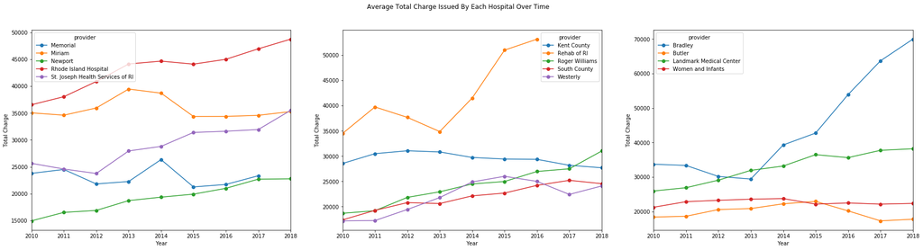

```python
fig, ax =plt.subplots(1,3, figsize=(30,7))
df33.groupby(['yod','provider']).mean()['tot'].unstack().plot(ax=ax[0], marker='o')
df34.groupby(['yod','provider']).mean()['tot'].unstack().plot(ax=ax[1], marker='o')
df35.groupby(['yod','provider']).mean()['tot'].unstack().plot(ax=ax[2], marker='o')

for i in ax.flat:
    i.set(xlabel='Year', ylabel='Total Charge')

fig.suptitle('Average Total Charge Issued By Each Hospital Over Time')
fig.show()
```

# #4 What is the most common race/ethnicity of patients for each hospital?

There is a lot of pre-processing here and I believe there is a simpler way to go about answering this question. Anyways, I have all my steps below.

```python
df4= df[['provider','raceethn', 'payer']].copy()

df4 = df4[df4['raceethn'].isin(['1.0', '2.0', '3.0','4.0','5.0','6.0','7.0','8.0','9.0'])].sort_values(['provider','payer','raceethn'], ascending=[True, True, True])

df4.head()
```

|  | provider | raceethn | payer |
| --- | --- | --- | --- |
| 1444 | 7201 | 1.0 | 0 |
| 1456 | 7201 | 1.0 | 0 |
| 1460 | 7201 | 1.0 | 0 |
| 1466 | 7201 | 1.0 | 0 |
| 1618 | 7201 | 1.0 | 0 |

```python
df7201= df4[df4['provider'].isin(['7201'])]
df7202= df4[df4['provider'].isin(['7202'])]
df7203= df4[df4['provider'].isin(['7203'])]
df7204= df4[df4['provider'].isin(['7204'])]
df7205= df4[df4['provider'].isin(['7205'])]
df7206= df4[df4['provider'].isin(['7206'])]
df7209= df4[df4['provider'].isin(['7209'])]
df7210= df4[df4['provider'].isin(['7210'])]
df7211= df4[df4['provider'].isin(['7211'])]
df7212= df4[df4['provider'].isin(['7212'])]
df7213= df4[df4['provider'].isin(['7213'])]
df7214= df4[df4['provider'].isin(['7214'])]
df7215= df4[df4['provider'].isin(['7215'])]
df7216= df4[df4['provider'].isin(['7216'])]
```

```python
out7201= df7201.groupby(['provider','raceethn']).count().sort_values(['provider','payer','raceethn'], ascending=[True, False, True])
grouped_df7201 = out7201.groupby("provider")
top_n_rows7201 = grouped_df7201.head(3).reset_index()

out7202= df7202.groupby(['provider','raceethn']).count().sort_values(['provider','payer','raceethn'], ascending=[True, False, True])
grouped_df7202 = out7202.groupby("provider")
top_n_rows7202 = grouped_df7202.head(3).reset_index()

out7203= df7203.groupby(['provider','raceethn']).count().sort_values(['provider','payer','raceethn'], ascending=[True, False, True])
grouped_df7203 = out7203.groupby("provider")
top_n_rows7203 = grouped_df7203.head(3).reset_index()

out7204= df7204.groupby(['provider','raceethn']).count().sort_values(['provider','payer','raceethn'], ascending=[True, False, True])
grouped_df7204 = out7204.groupby("provider")
top_n_rows7204 = grouped_df7204.head(3).reset_index()

out7205= df7205.groupby(['provider','raceethn']).count().sort_values(['provider','payer','raceethn'], ascending=[True, False, True])
grouped_df7205 = out7205.groupby("provider")
top_n_rows7205 = grouped_df7205.head(3).reset_index()

out7206= df7206.groupby(['provider','raceethn']).count().sort_values(['provider','payer','raceethn'], ascending=[True, False, True])
grouped_df7206 = out7206.groupby("provider")
top_n_rows7206 = grouped_df7206.head(3).reset_index()

out7209= df7209.groupby(['provider','raceethn']).count().sort_values(['provider','payer','raceethn'], ascending=[True, False, True])
grouped_df7209 = out7209.groupby("provider")
top_n_rows7209 = grouped_df7209.head(3).reset_index()

out7210= df7210.groupby(['provider','raceethn']).count().sort_values(['provider','payer','raceethn'], ascending=[True, False, True])
grouped_df7210 = out7210.groupby("provider")
top_n_rows7210 = grouped_df7210.head(3).reset_index()

out7211= df7211.groupby(['provider','raceethn']).count().sort_values(['provider','payer','raceethn'], ascending=[True, False, True])
grouped_df7211 = out7211.groupby("provider")
top_n_rows7211 = grouped_df7211.head(3).reset_index()

out7212= df7212.groupby(['provider','raceethn']).count().sort_values(['provider','payer','raceethn'], ascending=[True, False, True])
grouped_df7212 = out7212.groupby("provider")
top_n_rows7212 = grouped_df7212.head(3).reset_index()

out7213= df7213.groupby(['provider','raceethn']).count().sort_values(['provider','payer','raceethn'], ascending=[True, False, True])
grouped_df7213 = out7213.groupby("provider")
top_n_rows7213 = grouped_df7213.head(3).reset_index()


out7214= df7214.groupby(['provider','raceethn']).count().sort_values(['provider','payer','raceethn'], ascending=[True, False, True])
grouped_df7214 = out7214.groupby("provider")
top_n_rows7214 = grouped_df7214.head(3).reset_index()

out7215= df7215.groupby(['provider','raceethn']).count().sort_values(['provider','payer','raceethn'], ascending=[True, False, True])
grouped_df7215 = out7215.groupby("provider")
top_n_rows7215 = grouped_df7215.head(3).reset_index()

out7216= df7216.groupby(['provider','raceethn']).count().sort_values(['provider','payer','raceethn'], ascending=[True, False, True])
grouped_df7216 = out7216.groupby("provider")
top_n_rows7216 = grouped_df7216.head(3).reset_index()
```

```python
frames = [top_n_rows7201, top_n_rows7202, top_n_rows7203, top_n_rows7204, top_n_rows7205, top_n_rows7206,
         top_n_rows7209, top_n_rows7210, top_n_rows7211, top_n_rows7212, top_n_rows7213, top_n_rows7214,
         top_n_rows7215, top_n_rows7216]

result = pd.concat(frames)
```

```python
df7201= df7201[df7201['raceethn'].isin(['1.0', '2.0', '9.0'])]
df7202= df7202[df7202['raceethn'].isin(['1.0', '2.0', '7.0'])]
df7203= df7203[df7203['raceethn'].isin(['1.0', '2.0', '7.0'])]
df7204= df7204[df7204['raceethn'].isin(['1.0', '2.0', '7.0'])]
df7205= df7205[df7205['raceethn'].isin(['1.0', '2.0', '7.0'])]
df7206= df7206[df7206['raceethn'].isin(['1.0', '2.0', '7.0'])]
df7209= df7209[df7209['raceethn'].isin(['1.0', '2.0', '4.0'])]
df7210= df7210[df7210['raceethn'].isin(['1.0', '2.0', '7.0'])]
df7211= df7211[df7211['raceethn'].isin(['1.0', '2.0', '7.0'])]
df7212= df7212[df7212['raceethn'].isin(['1.0', '2.0', '7.0'])]
df7213= df7213[df7213['raceethn'].isin(['1.0', '2.0', '7.0'])]
df7214= df7214[df7214['raceethn'].isin(['1.0', '2.0', '7.0'])]
df7215= df7215[df7215['raceethn'].isin(['1.0', '2.0', '7.0'])]
df7216= df7216[df7216['raceethn'].isin(['1.0', '2.0', '7.0'])]
```

```python
frames2 = [df7201, df7202, df7203, df7204, df7205, df7206, df7209, df7210, df7211, df7212, df7213, df7214, df7215, df7216]

result2 = pd.concat(frames2)
```

```python
Provider_df = pd.DataFrame([[7201,'Newport'],
[7202,'St. Joseph Health Services of RI'],
[7203,'Memorial'],
[7204,'Miriam'],
[7205,'Rhode Island Hospital'],
[7206,'Roger Williams'],
[7209,'South County'],
[7210,'Kent County'],
[7211,'Westerly'],
[7212,'Rehab of RI'],
[7213,'Landmark Medical Center'],
[7214,'Women and Infants'],
[7215,'Bradley'],
[7216,'Butler']])

result2['provider'] = result2['provider'].replace(list(Provider_df[0]),list(Provider_df[1]))
```

```python
RaceE_df = pd.DataFrame([[1, 'White'],
                            [2, 'Black'],
                            [3, 'Asian'],
                            [4, 'American Indian'],
                            [5, 'Native Hawaiian'],
                            [6, 'Other'],
                            [7, 'Hispanic'],
                            [9, 'Information Not Available']])

result2['raceethn'] = result2['raceethn'].replace(list(RaceE_df[0]),list(RaceE_df[1]))
result2 =result2.fillna(0)
RaceE2_df = pd.DataFrame([[0, 'Information Not Available']])
result2['raceethn'] = result2['raceethn'].replace(list(RaceE2_df[0]),list(RaceE2_df[1]))
```

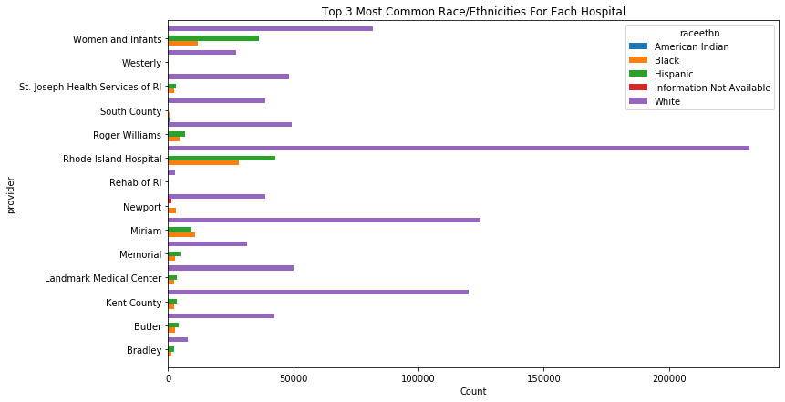

```python
fig, ax = plt.subplots(figsize=(12,7))
plt.title('Top 3 Most Common Race/Ethnicities For Each Hospital')
plt.xlabel('Count')
plt.ylabel('Provider')
result2.groupby(['provider','raceethn']).count()['payer'].unstack().plot(kind='barh', ax=ax, width= 1)
```

The only thing I don't like about this visualization is the whitespace in between some of the bars if the data for that race/ethn is either very small or does not exist. I could have just limited the output to the top 3 race/ethn overall, but since the question was to answer that per hospital I did not filter the data any further.

# #5 What is the most common month for patients to enter and leave the hospital?

```python
df5= df[['moa', 'mod']].copy()
df5 = df5[df5['moa'].isin(['January','February','March','April','May','June','July', 'August', 'September',
'October', 'November', 'December'])]
```

```python
Provider_df = pd.DataFrame([['January',1],
['February',2],
['March', 3],
['April', 4],
['May', 5],
['June', 6],
['July', 7],
['August', 8],
['September', 9],
['October', 10],
['November', 11],
['December', 12]])

df5['mod'] = df5['mod'].replace(list(Provider_df[0]),list(Provider_df[1]))
df5['moa'] = df5['moa'].replace(list(Provider_df[0]),list(Provider_df[1]))

df5.sort_values(by=['moa','mod'], inplace=True)

Provider_df = pd.DataFrame([[1, 'January'],
[2, 'February'],
[3, 'March'],
[4, 'April'],
[5, 'May'],
[6, 'June'],
[7, 'July'],
[8, 'August'],
[9, 'September'],
[10, 'October'],
[11, 'November'],
[12, 'December']])

df5['mod'] = df5['mod'].replace(list(Provider_df[0]),list(Provider_df[1]))
df5['moa'] = df5['moa'].replace(list(Provider_df[0]),list(Provider_df[1]))


df5.head()
#df5.dtypes()
```

|  | moa | mod |
| --- | --- | --- |
| 823 | January | January |
| 824 | January | January |
| 825 | January | January |
| 826 | January | January |
| 827 | January | January |

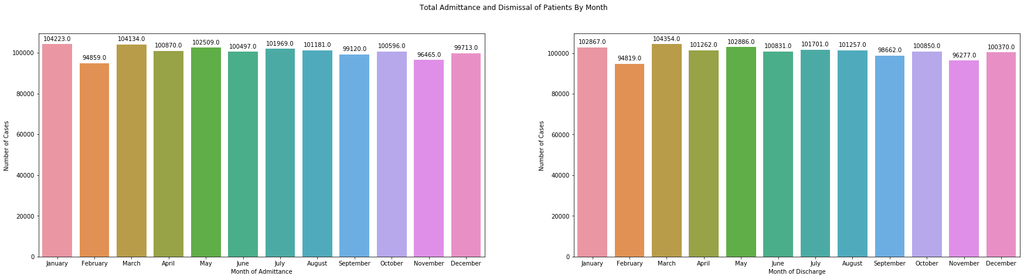

```python
fig, ax =plt.subplots(1,2, figsize=(30,7))
splot= sns.countplot(df5['moa'], ax=ax[0])
ax[0].set(xlabel='Month of Admittance')
splot1= sns.countplot(df5['mod'], ax=ax[1])
ax[1].set(xlabel='Month of Discharge')

for p in splot.patches:
    splot.annotate(format(p.get_height(), '.1f'),
                   (p.get_x() + p.get_width() / 2., p.get_height()),
                   ha = 'center', va = 'center',
                   xytext = (0, 9),
                   textcoords = 'offset points')

for p in splot1.patches:
    splot1.annotate(format(p.get_height(), '.1f'),
                   (p.get_x() + p.get_width() / 2., p.get_height()),
                   ha = 'center', va = 'center',
                   xytext = (0, 9),
                   textcoords = 'offset points')

for i in ax.flat:
    i.set(ylabel='Number of Cases')

fig.suptitle('Total Admittance and Dismissal of Patients By Month')
fig.show()
fig.show()
```

Based on the data, the most common month to enter the hospital is January (104,223) and the most common month to leave is March (104,354).